# a Radiocarbon review: databases, calibrations and interactive apps

Thomas Huet

# Presentation

Today exists various web-based ressources for database, calibrations and **interactive selection and spatialization**,

# Radiocarbon ressources

Free ressources exist for radiocarbon apps, databases, calibrations or for analysis

## applications

| names | url |
| --- | --- |
| MedAfriCarbon | https://theia.arch.cam.ac.uk/MedAfriCarbon/ |
| NeoNet | https://zoometh.github.io/C14/neonet |
| EUROEVOL_R | https://neolithic.shinyapps.io/Euroevol_R/ |
| c14bazAAR | https://github.com/ropensci/c14bazAAR |
| GoGet | https://www.ibercrono.org/goget/index.php |

**MedAfriCarbon**, **NeoNet** and **EUROEVOL_R** allow interactive web form map-based for of radiocarbon dates selection by geographical region of interest, time span and periods, quality of the date, etc. These apps offer also analysis tools like summing probability densities (SPD).

These apps have been developped with [R](https://www.r-project.org/) programming language and the [Shiny](https://shiny.rstudio.com/) package

### **MedAfriCarbon** app

- **[MedAfriCarbon app](https://theia.arch.cam.ac.uk/MedAfriCarbon/)** covers the South Mediterranean between the beginning of the Holocene ) and the arrival of Phoenicians and Greeks (ca. 9,600 - 600 BC) with near 1,600 radiocarbon dates

[figure not shown]

The [MedAfriCarbon](https://theia.arch.cam.ac.uk/MedAfriCarbon/) RShiny app offers additional options for selection and calibration of radiocarbon dates

### **NeoNet** and **EUROEVOL_R** apps

**NeoNet** and **EUROEVOL_R** share the same layout, mostly inherited from the EUROEVOL database, only the datasets are differents

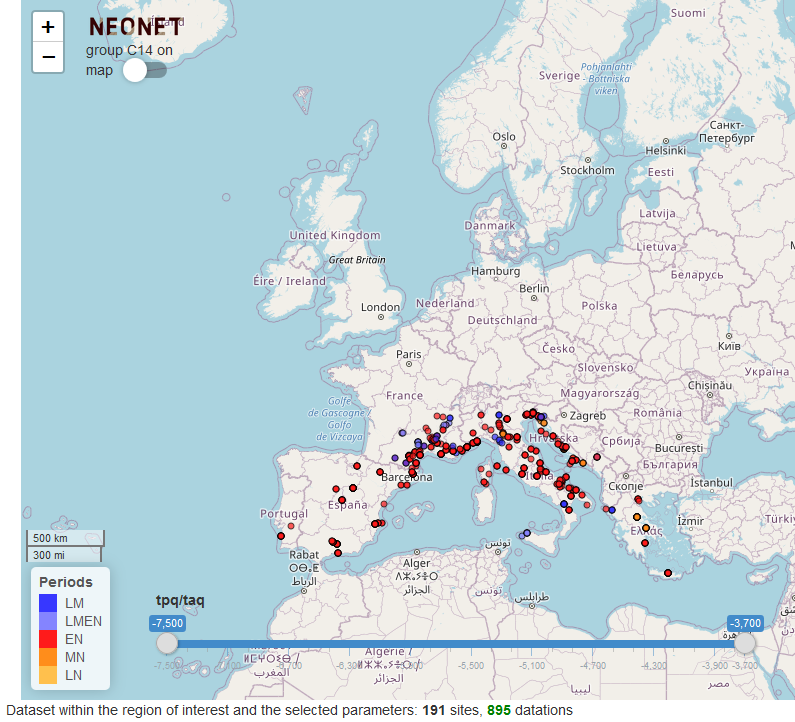

The database, an Excel Sheet, see the [**NeoNet app** webpage](https://zoometh.github.io/C14/neonet/#app)

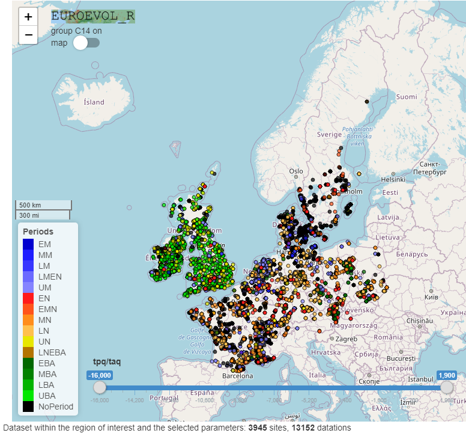

The app database is the [EUROEVOL database](http://discovery.ucl.ac.uk/1469811/), is opensource and static (yet developed), see the [**EUROEVOL_R app** webpage](https://zoometh.github.io/C14/euroevol)

## databases

An almost exhaustive inventory of open databases has been made on the [c14bazAAR repository](https://github.com/ropensci/c14bazAAR#databases)

| names | url |
| --- | --- |
| EUROEVOL | http://discovery.ucl.ac.uk/1469811 |
| Radon | https://radon.ufg.uni-kiel.de/ |
| ORAU | https://c14.arch.ox.ac.uk |
| telearchaeology | http://telearchaeology.org/c14-databses/ |
| Archaeological Site Index to Radiocarbon Dates from Great Britain and Ireland | http://www.britarch.ac.uk/info/c14.html |
| 14SEA Project | http://www.14sea.org/2_dates.html |
| EX ORIENTE | https://www.exoriente.org/associated_projects/ppnd_sites.php |
| BANADORA | http://www.archeometrie.mom.fr/banadora/ |

## calibrations

| type | names | url |
| --- | --- | --- |
| dedicated | OxCal | https://c14.arch.ox.ac.uk/oxcal/ |
| dedicated | CalPal | http://www.calpal-online.de/ |
| dedicated | Calib | http://calib.org/calib/ |
| R programming | rcarbon | https://cran.r-project.org/web/packages/rcarbon/index.html |
| R programming | Bchron | https://cran.r-project.org/web/packages/Bchron/index.html |
| R programming | oxcAAR | https://cran.r-project.org/web/packages/oxcAAR/index.html |

## analysis

R offers a comprehensive framework to calibrate, plot, sum and use temporal constraints – stratigraphy, periodisations, etc., like bayesian analysis – on radiocarbon datasets. Free software offering a dedicated solution for bayesian inference are: [ChronoModel](https://chronomodel.com/), [OpenBUGS](http://www.openbugs.net/w/FrontPage), [JAGS](http://mcmc-jags.sourceforge.net/), etc.

For a overview of the available solutions, see the [R Bayesian task view](https://cran.r-project.org/web/views/Bayesian.html)